# Copper Regression

## Penalized parameter selection

We employ LASSO (Least Absolute Shrinkage and Selection Operator) regression to select parameters that minimize model complexity. It uses a loss function and penalty parameter (lambda) to estimate regression coefficients.

We start with all potential predictors and interactions.

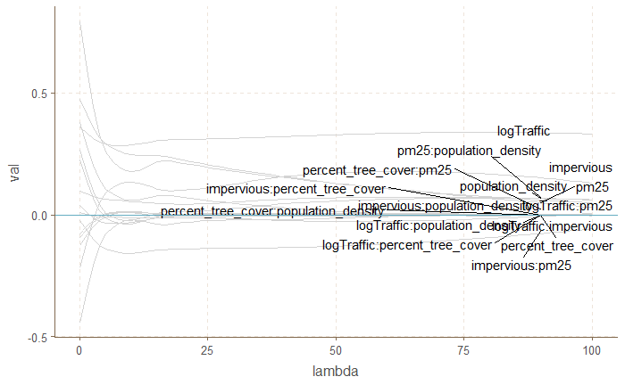

```r
#make a formula with all predictors
formula.1 <-
  as.formula(
    logConcentration ~ logTraffic + impervious + percent_tree_cover + pm25 + population_density
      + logTraffic:impervious + logTraffic:percent_tree_cover + logTraffic:population_density +
      logTraffic:pm25 + impervious:percent_tree_cover + impervious:pm25 + impervious:population_density
      + percent_tree_cover:pm25 + percent_tree_cover:population_density + pm25:population_density
  )
# Run the function (can take a while for a lot of parameters)
param.select.1 <- selectLasso(formula.1, df.transformed)


# plot the results
ggplot(param.select.1) +
  geom_smooth(aes(x = lambda, y = val, group = predictor), color = "light grey", se = FALSE, size = 0.1) +
  geom_text_repel(
    data = param.select.1 %>%
      filter(lambda == last(lambda)),
    aes(label = predictor, x = lambda * 0.9, y = val * 1.2), label.size = 0.01
  ) +
  theme(legend.position = "none") +
  geom_hline(yintercept = 0)
```

```r
# display the last lambda
kable(param.select.1 %>%
  filter(lambda == last(lambda)))
```

| (Intercept) | lambda | predictor | val |
| --- | --- | --- | --- |
| 10.2 | 100 | logTraffic | 0.324 |
| 10.2 | 100 | impervious | 0.136 |
| 10.2 | 100 | percent_tree_cover | 0.000 |
| 10.2 | 100 | pm25 | 0.042 |
| 10.2 | 100 | population_density | 0.057 |
| 10.2 | 100 | logTraffic:impervious | 0.000 |
| 10.2 | 100 | logTraffic:percent_tree_cover | 0.000 |
| 10.2 | 100 | logTraffic:population_density | 0.000 |
| 10.2 | 100 | logTraffic:pm25 | 0.000 |
| 10.2 | 100 | impervious:percent_tree_cover | 0.000 |
| 10.2 | 100 | impervious:pm25 | -0.057 |
| 10.2 | 100 | impervious:population_density | 0.000 |
| 10.2 | 100 | percent_tree_cover:pm25 | 0.020 |
| 10.2 | 100 | percent_tree_cover:population_density | 0.000 |
| 10.2 | 100 | pm25:population_density | 0.059 |

This chart is kind of a mess, but it shows that many predictors quickly go to zero as the loss function increases in penalty. We will remove these and show the predictors that seem to hold up. Make this clearer:

```r
formula.2 <- (as.formula(logConcentration ~ logTraffic + percent_tree_cover + pm25 + impervious + population_density))
param.select.2 <- selectLasso(formula.2, df.transformed)
```

[output not shown]

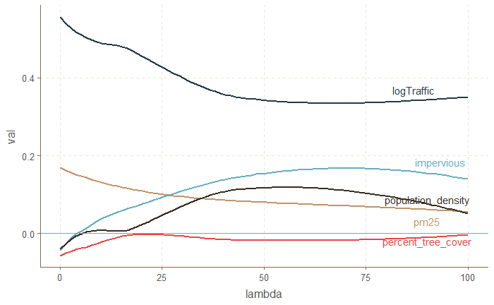

```r
ggplot(param.select.2) +
  geom_smooth(aes(x = lambda, y = val, color = predictor), se = FALSE) +
  geom_text_repel(
    data = param.select.2 %>%
      filter(lambda == last(lambda)),
    aes(label = predictor, x = lambda * 0.9, y = val * 1.2, color = predictor)
  ) +
  geom_hline(yintercept = 0) +
  theme(legend.position = "none")
```

```r
kable(param.select.2 %>%
  filter(lambda == last(lambda)))
```

| (Intercept) | lambda | predictor | val |
| --- | --- | --- | --- |
| 10.2 | 100 | logTraffic | 0.324 |
| 10.2 | 100 | percent_tree_cover | 0.000 |
| 10.2 | 100 | pm25 | 0.042 |
| 10.2 | 100 | impervious | 0.136 |
| 10.2 | 100 | population_density | 0.057 |

# Begin Fitting a model

Now it is time to begin with model fitting. We use the `gamlss` package, an additive univariate regression model that can include non-linear relationships, random effects, and various parametric distributions.

## Step 1 - Model with no random effects

We begin with our fitting our null hypotheses. We actually have to null hypotheses.

- H.null.a: There is not a relationship between predictors.
- H.null.b: Land use is the best predictor.

```r
lm.2 <- gamlss(concentration ~
logTraffic + pm25 , data = df.coc, family = LOGNO)
```

```
GAMLSS-RS iteration 1: Global Deviance = 9722
GAMLSS-RS iteration 2: Global Deviance = 9722
```

### Step 1 Results

```r
##huxtablereg(mods.step1,single.row = T)
screenreg(mods.step1,single.row=T)
```

```
=====================================================================================================
                       Model 1             Model 2             Model 3             Model 4
-----------------------------------------------------------------------------------------------------
mu (Intercept)           10.17 (0.06) ***    10.44 (0.10) ***     8.25 (0.51) ***     8.08 (0.41) ***
sigma (Intercept)         0.24 (0.03) ***     0.18 (0.03) ***     0.12 (0.03) ***     0.12 (0.03) ***
mu typeHDR                                   -0.29 (0.14) *
mu typeIND                                    0.54 (0.23) *
mu typeLDR                                   -0.99 (0.16) ***
mu logTraffic                                                     0.26 (0.04) ***     0.24 (0.03) ***
mu pm25                                                           0.23 (0.10) *       0.22 (0.08) **
mu impervious                                                    -0.21 (0.36)
mu population_density                                            -0.03 (0.05)
mu percent_tree_cover                                            -0.00 (0.00)
-----------------------------------------------------------------------------------------------------
Num. obs.               415                 415                 415                 415
Nagelkerke R^2            0.00                0.12                0.21                0.21
Generalized AIC        9825.17             9778.70             9735.11             9730.21
=====================================================================================================
*** p < 0.001; ** p < 0.01; * p < 0.05
```

Based on AIC, model 4 seems to be the best model. It outperforms the null models.

```r
best.step1 <- mods.step1[[4]]
```

## Step 2 - Adjust scale parameter

GAMLSS includes a scale parameter `sigma`, which can be used to adjust the distribution standard deviation. Here we try different sigma formulas.

```r
step1.formula <- formula(best.step1)

mod.step2.1 <- gamlss(step1.formula,
  data = df.coc, family = LOGNO,
  trace = F,
  sigma.formula = ~study_id
)

mod.step2.2 <- gamlss(step1.formula,
  data = df.coc, family = LOGNO,
  trace = F,
  sigma.formula = ~AMC
)
mod.step2.3 <- gamlss(step1.formula,
  data = df.coc, family = LOGNO,
  trace = F,
  sigma.formula = ~season
)

# create list of models. Include the best from the previous step.

mods.step2 <- list(best.step1, mod.step2.1, mod.step2.2, mod.step2.3)
```

### Step 2 Results

```r
# display results
screenreg(mods.step2,single.row=T)
```

```
===========================================================================================================
                             Model 1             Model 2             Model 3             Model 4
-----------------------------------------------------------------------------------------------------------
mu (Intercept)                  8.08 (0.41) ***     8.27 (0.45) ***     8.13 (0.41) ***     8.08 (0.40) ***
mu logTraffic                   0.24 (0.03) ***     0.24 (0.03) ***     0.24 (0.03) ***     0.25 (0.03) ***
mu pm25                         0.22 (0.08) **      0.20 (0.08) *       0.21 (0.07) **      0.22 (0.07) **
sigma (Intercept)               0.12 (0.03) ***     0.36 (0.09) ***     0.20 (0.06) ***     0.10 (0.06)
sigma study_idWAR044003_S8D                        -0.47 (0.15) **
sigma study_idWAR044200_S8D                        -0.29 (0.16)
sigma study_idWAR044501_S8D                        -0.22 (0.13)
sigma study_idWAR044502_S8D                        -0.11 (0.11)
sigma study_idWAR044503_S8D                        -0.64 (0.12) ***
sigma AMCAMC_2                                                         -0.09 (0.08)
sigma AMCAMC_3                                                         -0.18 (0.10)
sigma season2                                                                               0.10 (0.10)
sigma season3                                                                               0.09 (0.12)
sigma season4                                                                              -0.04 (0.08)
-----------------------------------------------------------------------------------------------------------
Num. obs.                     415                 415                 415                 415
Nagelkerke R^2                  0.21                0.28                0.22                0.22
Generalized AIC              9730.21             9702.23             9730.62             9733.71
===========================================================================================================
*** p < 0.001; ** p < 0.01; * p < 0.05
```

```r
best.step2 <- mods.step2[[2]]
```

## Step 3 - Explore non-linear relationships

```r
#get the formula
step2.formula <- formula(best.step2)

# make new formulas by updating previous steps
step3.1.formula <- update(step2.formula, . ~ . - logTraffic - pm25 + pbm(logTraffic) + pbm(pm25))
step3.2.formula <- update(step2.formula, . ~ . - logTraffic + pbm(logTraffic))
step3.3.formula <- update(step2.formula, . ~ . - pm25 + pbm(pm25))
step3.4.formula <- update(step2.formula, . ~ . - logTraffic - pm25 + pbm(logTraffic))

# fit models
mod.step3.1 <- gamlss(
  step3.1.formula,
  data = df.coc,
  family = LOGNO,
  trace = F,
  sigma.formula = ~season
)

mod.step3.2 <- gamlss(
  step3.2.formula,
  data = df.coc,
  family = LOGNO,
  trace = F,
  sigma.formula = ~season
)

mod.step3.3 <- gamlss(
  step3.3.formula,
  data = df.coc,
  family = LOGNO,
  trace = F,
  sigma.formula = ~season
)

mod.step3.4 <- gamlss(
  step3.4.formula,
  data = df.coc,
  family = LOGNO,
  trace = F,
  sigma.formula = ~season
)


# make a list of models
mods.step3 <- list(best.step2, mod.step3.1, mod.step3.2, mod.step3.3, mod.step3.4)
```

### Step 3 Results

```r
# display results
screenreg(mods.step3, single.row = T)
```

```
===============================================================================================================================
                             Model 1             Model 2             Model 3             Model 4             Model 5
-------------------------------------------------------------------------------------------------------------------------------
mu (Intercept)                  8.27 (0.45) ***    10.18 (0.05) ***     8.98 (0.39) ***     9.29 (0.11) ***    10.18 (0.06) ***
mu logTraffic                   0.24 (0.03) ***                                             0.24 (0.03) ***
mu pm25                         0.20 (0.08) *                           0.22 (0.07) **
sigma (Intercept)               0.36 (0.09) ***     0.06 (0.06)         0.08 (0.06)         0.08 (0.06)         0.08 (0.06)
sigma study_idWAR044003_S8D    -0.47 (0.15) **
sigma study_idWAR044200_S8D    -0.29 (0.16)
sigma study_idWAR044501_S8D    -0.22 (0.13)
sigma study_idWAR044502_S8D    -0.11 (0.11)
sigma study_idWAR044503_S8D    -0.64 (0.12) ***
sigma season2                                       0.10 (0.10)         0.08 (0.10)         0.12 (0.10)         0.08 (0.10)
sigma season3                                       0.13 (0.12)         0.12 (0.12)         0.08 (0.12)         0.12 (0.12)
sigma season4                                      -0.03 (0.08)        -0.04 (0.08)        -0.03 (0.08)        -0.03 (0.08)
-------------------------------------------------------------------------------------------------------------------------------
Num. obs.                     415                 415                 415                 415                 415
Nagelkerke R^2                  0.28                0.28                0.25                0.23                0.24
Generalized AIC              9702.23             9709.43             9717.06             9725.99             9723.29
===============================================================================================================================
*** p < 0.001; ** p < 0.01; * p < 0.05
```

```r
best.step3 <- mods.step3[[2]]
step3.formula <- formula(best.step3)
```

## Step 4 - Select random effects

```r
mod.step4.3 <- gamlss(formula.step4.3,
  family = LOGNO,
    sigma.formula = ~study_id,
  trace = F,
  data = df.coc, method = mixed()
)
```

```
Algorithm CG has not yet converged
```

### Step 4 results

```r
#display results
screenreg(mods.step4, single.row = T)
```

```
===============================================================================================================================
                             Model 1             Model 2             Model 3             Model 4             Model 5
-------------------------------------------------------------------------------------------------------------------------------
mu (Intercept)                  8.27 (0.45) ***     8.02 (0.40) ***     8.02 (0.40) ***     8.80 (0.36) ***     8.21 (0.44) ***
mu logTraffic                   0.24 (0.03) ***     0.24 (0.03) ***     0.24 (0.03) ***     0.21 (0.02) ***     0.23 (0.03) ***
mu pm25                         0.20 (0.08) *       0.23 (0.07) **      0.23 (0.07) **      0.11 (0.07)         0.21 (0.08) **
sigma (Intercept)               0.36 (0.09) ***     0.11 (0.03) **      0.11 (0.03) **      0.26 (0.09) **      0.34 (0.09) ***
sigma study_idWAR044003_S8D    -0.47 (0.15) **                                             -0.38 (0.15) *      -0.44 (0.15) **
sigma study_idWAR044200_S8D    -0.29 (0.16)                                                -0.22 (0.15)        -0.27 (0.16)
sigma study_idWAR044501_S8D    -0.22 (0.13)                                                -0.23 (0.12)        -0.18 (0.13)
sigma study_idWAR044502_S8D    -0.11 (0.11)                                                -0.06 (0.11)        -0.09 (0.11)
sigma study_idWAR044503_S8D    -0.64 (0.12) ***                                            -0.57 (0.11) ***    -0.63 (0.12) ***
-------------------------------------------------------------------------------------------------------------------------------
Num. obs.                     415                 415                 415                 415                 415
Nagelkerke R^2                  0.28                0.23                0.23                0.36                0.29
Generalized AIC              9702.23             9726.42             9726.42             9664.18             9701.28
===============================================================================================================================
*** p < 0.001; ** p < 0.01; * p < 0.05
```

```r
best.step4 <- mods.step4[[4]]
```

## Summary of best bodel from steps 1-4

```r
#display a summary
summary(best.step4)
```

```
Family:  c("LOGNO", "Log Normal")

Call:  gamlss(formula = formula.step4.2, sigma.formula = ~study_id,
    family = LOGNO, data = df.coc, trace = F)

Fitting method: RS()

------------------------------------------------------------------
Mu link function:  identity
Mu Coefficients:
            Estimate Std. Error t value Pr(>|t|)
(Intercept)   8.7954     0.3577   24.59  < 2e-16 ***
logTraffic    0.2083     0.0248    8.39  8.1e-16 ***
pm25          0.1100     0.0658    1.67    0.095 .
---
Signif. codes:  0 ‘***’ 0.001 ‘**’ 0.01 ‘*’ 0.05 ‘.’ 0.1 ‘ ’ 1

------------------------------------------------------------------
Sigma link function:  log
Sigma Coefficients:
                      Estimate Std. Error t value Pr(>|t|)
(Intercept)             0.2616     0.0880    2.97   0.0031 **
study_idWAR044003_S8D  -0.3789     0.1529   -2.48   0.0136 *
study_idWAR044200_S8D  -0.2215     0.1515   -1.46   0.1446
study_idWAR044501_S8D  -0.2319     0.1208   -1.92   0.0556 .
study_idWAR044502_S8D  -0.0592     0.1117   -0.53   0.5962
study_idWAR044503_S8D  -0.5723     0.1134   -5.05  6.9e-07 ***
---
Signif. codes:  0 ‘***’ 0.001 ‘**’ 0.01 ‘*’ 0.05 ‘.’ 0.1 ‘ ’ 1

------------------------------------------------------------------
NOTE: Additive smoothing terms exist in the formulas:
 i) Std. Error for smoothers are for the linear effect only.
ii) Std. Error for the linear terms maybe are not accurate.
------------------------------------------------------------------
No. of observations in the fit:  415
Degrees of Freedom for the fit:  14.2
      Residual Deg. of Freedom:  401
                      at cycle:  5

Global Deviance:     9636
            AIC:     9664
            SBC:     9722
```

# Grouped K-Fold Cross validation

We use cross-validation with grouped folds to find the best model, and then test that model on a subset of the original data. Since our data is grouped by Location, we assign a fold for each location.

Split the data into folds by Location.

```r
folds <-(as.numeric(df.coc$Location))
(max(folds)) #check number of folds
```

```
[1] 14
```

We have 14 folds, one for each location.

Make a list of models to validate, run through the cross-validation function and show the results.

```r
models.to.validate <-
  list(
    "nulla" = model.nulla,
    "nullb" = model.nullb,
    "step1" = best.step1,
    "step2" = best.step2,
    "step3" = best.step3,
    "step4" = best.step4
  )

cv.results <- cv.function(models.to.validate)
```

## Cross validation results

Show the resulting average AIC from the cross-validation results.

```r
print(cv.results)
```

| model | GAIC |
| --- | --- |
| nulla | 9852 |
| nullb | 9848 |
| step1 | 9783 |
| step2 | 9789 |
| step3 | 9789 |
| step4 | NA |

# Results

```r
selected_model <- best.step2
summary(selected_model)
```

```
Family:  c("LOGNO", "Log Normal")

Call:  gamlss(formula = step1.formula, sigma.formula = ~study_id,
    family = LOGNO, data = df.coc, trace = F)

Fitting method: RS()

------------------------------------------------------------------
Mu link function:  identity
Mu Coefficients:
            Estimate Std. Error t value Pr(>|t|)
(Intercept)   8.2676     0.4458   18.55   <2e-16 ***
logTraffic    0.2386     0.0266    8.98   <2e-16 ***
pm25          0.2000     0.0807    2.48    0.014 *
---
Signif. codes:  0 ‘***’ 0.001 ‘**’ 0.01 ‘*’ 0.05 ‘.’ 0.1 ‘ ’ 1

------------------------------------------------------------------
Sigma link function:  log
Sigma Coefficients:
                      Estimate Std. Error t value Pr(>|t|)
(Intercept)             0.3572     0.0903    3.96  9.0e-05 ***
study_idWAR044003_S8D  -0.4746     0.1544   -3.07   0.0023 **
study_idWAR044200_S8D  -0.2882     0.1572   -1.83   0.0675 .
study_idWAR044501_S8D  -0.2205     0.1344   -1.64   0.1016
study_idWAR044502_S8D  -0.1056     0.1119   -0.94   0.3457
study_idWAR044503_S8D  -0.6356     0.1165   -5.46  8.4e-08 ***
---
Signif. codes:  0 ‘***’ 0.001 ‘**’ 0.01 ‘*’ 0.05 ‘.’ 0.1 ‘ ’ 1

------------------------------------------------------------------
No. of observations in the fit:  415
Degrees of Freedom for the fit:  9
      Residual Deg. of Freedom:  406
                      at cycle:  5

Global Deviance:     9684
            AIC:     9702
            SBC:     9738
```

```
          Summary of the Quantile Residuals
                           mean   =  -0.0351
                       variance   =  1
               coef. of skewness  =  0.0926
               coef. of kurtosis  =  3.23
Filliben correlation coefficient  =  0.998
```

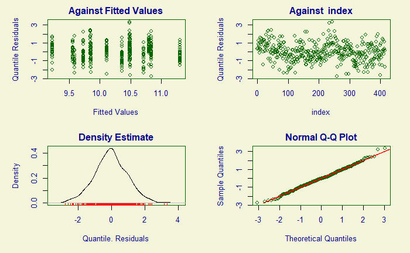

```r
plot(selected_model,summary=T)
```

Plot the predictions.

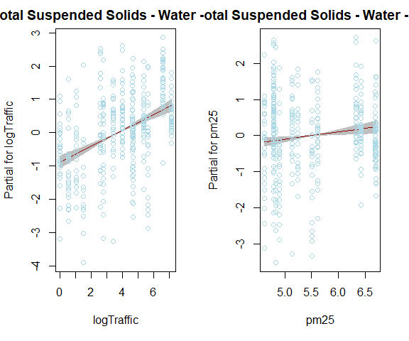

```r
term.plot(selected_model,what="mu",rug=F,pages=1,ask=F,partial.resid=T,ylim="free",main=coc)
```

# Hypotheses test results

1. Is the land use (nullb) model better than using average concentration (nulla) (i.e. single intercept; slope = 0)?

```r
#use Vuong and Clarke tests
VC.test(model.nulla,model.nullb)
```

```
 Vuong's test: -2.66 model model.nullb is preferred over model.nulla
Clarke's test: 156 p-value= 0 model.nullb is preferred over model.nulla
```

2. Is the selected model better than the land use only model?

```r
VC.test(model.nullb,selected_model)
```

```
 Vuong's test: -2.87 model selected_model is preferred over model.nullb
Clarke's test: 180 p-value= 0.008 selected_model is preferred over model.nullb
```

Plot results from the land use model vs. the selected model

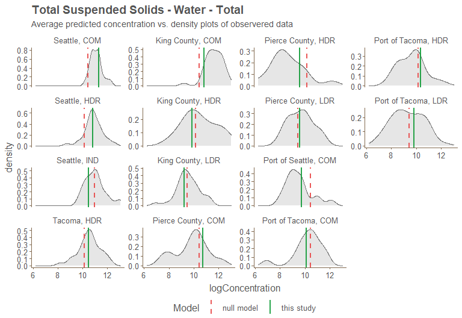

```r
diag.df <- add.fit(selected_model, df.coc)

diag.nullb <- add.fit(model.nullb, df.coc)

ggthemr('fresh', "clean", spacing = 0.8)
selected_model.fit <- diag.df %>%
  group_by(study_name, type) %>%
  summarize(Int = mean(.fit)) %>%
  add_column(model = "this study")
#
null_model.fit <- diag.nullb %>%
  group_by(study_name, type) %>%
  summarize(Int = mean(.fit)) %>%
  add_column(model = "null model")
#
model.fits <- rbind(selected_model.fit, null_model.fit)
#
summary.plot <- ggplot(diag.df, aes(x = logConcentration)) +
  geom_density(color = "#757575",
               fill = "#e0e0e0",
               alpha = 0.8) +
  geom_vline(
    data = model.fits,
    aes(
      xintercept = Int,
      group = model,
      color = model,
      linetype = (model)
    ),
    size = 1,
    #linetype = "solid",
    alpha = 0.9
  ) + legend_bottom() +
  scale_linetype_manual(
    name = "Model",
    breaks = c("null model", "this study"),
    labels = c("null model", "this study"),
    values = c('dashed', 'solid')
  ) + scale_color_manual(
    values = c("#E84646", "#109B37") ,
    name = "Model",
    breaks = c("null model", "this study"),
    labels = c("null model", "this study")
  ) +
  labs(title = coc, subtitle = "Average predicted concentration vs. density plots of observered data") +
  scale_y_continuous(labels = scales::number_format(accuracy = .1,
                                                    decimal.mark = '.'))


summary.plot +facet_wrap(study_name~type,
             drop = T,
             nrow = 4,
             scales = 'free_y',labeller=labeller(.multi_line = F),dir='v')  #,scales="free")+
```

```r
NA
NA
```

*fin*